# Tidyverse Recepie

Maliat Islam

4/8/2021

## Tidyverse Recepie:

### The Tidyverses is an collection of R packages.When Tidyverse is loaded it loads ggplot2, dplyr, tidyr, readr, purrr, tibble, stringr, and forcats.

### Forcats and ggplot:

#### For the implementation of Tidyverse, I have selected Forcats and ggplot libraries from this package.dplyr was used as well. I have selected Disney movies gross income dataset from the 1937-2016 from Kaggle.

#### The purpose this analysis is to categorized Disney movies according to their genre. Those movies gross income is also going to be analyzed.

#### https://www.kaggle.com/rashikrahmanpritom/disney-movies-19372016-total-gross

```r
library(tidyverse)
library(forcats)
library(kableExtra)
library(data.table)
disney_movies_total_gross <- read.csv("https://raw.githubusercontent.com/maliat-hossain/FileProcessing/main/disney_movies_total_gross.csv")
head(disney_movies_total_gross)%>% kable() %>%
  kable_styling(bootstrap_options = "striped", font_size = 10) %>%
  scroll_box(height = "500px", width = "100%")
```

| movie_title | release_date | genre | mpaa_rating | total_gross | inflation_adjusted_gross |
| --- | --- | --- | --- | --- | --- |
| Snow White and the Seven Dwarfs | 12/21/1937 | Musical | G | 184925485 | 5228953251 |
| Pinocchio | 2/9/1940 | Adventure | G | 84300000 | 2188229052 |
| Fantasia | 11/13/1940 | Musical | G | 83320000 | 2187090808 |
| Song of the South | 11/12/1946 | Adventure | G | 65000000 | 1078510579 |
| Cinderella | 2/15/1950 | Drama | G | 85000000 | 920608730 |
| 20,000 Leagues Under the Sea | 12/23/1954 | Adventure |  | 28200000 | 528279994 |

```r
DisneyMovies<-disney_movies_total_gross %>% dplyr::select(1)
DisneyMovies1<-DisneyMovies[1:10,]
```

#### The dataframe has been factorized for the purpose of implementing categories. The movies have been categorized as musical,adventure,comedy and drama.Forcats from tidyverse works really well to manipulate categorical variable.

```r
DisneyMovies2<-factor(DisneyMovies1)
view(DisneyMovies2)%>% kable() %>%
  kable_styling(bootstrap_options = "striped", font_size = 10) %>%
  scroll_box(height = "500px", width = "100%")
```

[output not shown]

```r
library(dplyr)
library(forcats)
library(ggplot2)
library(kableExtra)
library(tidyverse)

url <-
  "https://raw.githubusercontent.com/maliat-hossain/FileProcessing/main/disney_movies_total_gross.csv"

disney_movies_total_gross <-
  read.csv(url)

head(disney_movies_total_gross)%>%
  kable() %>%
    kable_styling(bootstrap_options = "striped",
                  font_size = 10) %>%
      scroll_box(height = "500px", width = "100%")
```

[output not shown]

#### Only necessary rows and columns have been selected using Tidyverse package dplyr. For this assignment I am focusing on the Disney movies released from 1937 to 1961.

```r
DisneyMovies<-
  disney_movies_total_gross %>%
    dplyr::select(1)

DisneyMovies1<-
  DisneyMovies[1:10,]
```

#### The dataframe has been factorized for the purpose of implementing categories. The movies have been categorized as musical,adventure,comedy and drama.Forcats from tidyverse works really well to manipulate categorical variable.

```r
DisneyMovies2<-
  factor(DisneyMovies1)

view(DisneyMovies2)%>%
  kable() %>%
    kable_styling(bootstrap_options = "striped",
                  font_size = 10) %>%
      scroll_box(height = "500px", width = "100%")
```

| x |
| --- |
| Snow White and the Seven Dwarfs |
| Pinocchio |
| Fantasia |
| Song of the South |
| Cinderella |
| 20,000 Leagues Under the Sea |
| Lady and the Tramp |
| Sleeping Beauty |
| 101 Dalmatians |
| The Absent Minded Professor |

```r
DisneyMovies2<-fct_recode(DisneyMovies2 ,Musical="Snow White and the Seven Dwarfs" ,Adventure="Pinocchio",Musical="Fantasia",Adventure ="Song of the South",Drama="Cinderella",Adventure="20,000 Leagues Under the Sea",Drama="Lady and the Tramp",Drama="Sleeping Beauty",Comedy="101 Dalmatians",Comedy="The Absent Minded Professor")
```

#### Total gross income column for these movies have been added.

```r
DisneyMovies3<-disney_movies_total_gross %>% dplyr::select(1,5)
DisneyMovies3<-DisneyMovies3[1:10,]
```

#### Summary statistics for total gross revenue from Disney movies has been calculated.

```r
summary(DisneyMovies3)
```

[output not shown]

```r
DisneyMovies2<-
  fct_recode(DisneyMovies2,
             Musical="Snow White and the Seven Dwarfs",
             Adventure="Pinocchio",
             Musical="Fantasia",
             Adventure="Song of the South",
             Drama="Cinderella",
             Adventure="20,000 Leagues Under the Sea",
             Drama="Lady and the Tramp",
             Drama="Sleeping Beauty",
             Comedy="101 Dalmatians",
             Comedy="The Absent Minded Professor")
```

#### Total gross income column for these movies have been added.

```r
DisneyMovies3<-
  disney_movies_total_gross %>%
    dplyr::select(1,5)

DisneyMovies3<-
  DisneyMovies3[1:10,]
```

#### Summary statistics for total gross revenue from Disney movies has been calculated.

```r
summary(DisneyMovies3)
```

```
##  movie_title         total_gross
##  Length:10          Min.   :  9464608
##  Class :character   1st Qu.: 37400000
##  Mode  :character   Median : 83810000
##                     Mean   : 81219150
##                     3rd Qu.: 91450000
##                     Max.   :184925485
```

#### case_when from dplyr is used for binning the gross income for movies.A variable named comparison_movies has been created which shows if the gross income of selected movie is “Below Average”, “Around Average”,or “Above Average”. To determine the average information from the summary statistics have been used.

```r
library(dplyr)
DisneyMovies4<-DisneyMovies3 %>%
  mutate(
    comparison_movies=case_when(
      total_gross < 81219150 ~ "Below Average",
      total_gross > 81219150  & total_gross <83810000 ~ "Around Average",
      TRUE ~ "Above Average"

    )
  )%>%
  select(movie_title,total_gross,comparison_movies)
```

```r
view(DisneyMovies4)%>% kable() %>%
  kable_styling(bootstrap_options = "striped", font_size = 10) %>%
  scroll_box(height = "500px", width = "100%")
```

[output not shown]

```r
DisneyMovies4<-
  DisneyMovies3 %>%
    mutate(comparison_movies=case_when(
      total_gross < 81219150 ~ "Below Average",
      total_gross > 81219150  & total_gross <83810000 ~ "Around Average",
      TRUE ~ "Above Average"))%>%
        select(movie_title,total_gross,comparison_movies)
```

```r
view(DisneyMovies4)%>%
  kable() %>%
    kable_styling(bootstrap_options = "striped",
                  font_size = 10) %>%
                scroll_box(height = "500px",
                         width = "100%")
```

| movie_title | total_gross | comparison_movies |
| --- | --- | --- |
| Snow White and the Seven Dwarfs | 184925485 | Above Average |
| Pinocchio | 84300000 | Above Average |
| Fantasia | 83320000 | Around Average |
| Song of the South | 65000000 | Below Average |
| Cinderella | 85000000 | Above Average |
| 20,000 Leagues Under the Sea | 28200000 | Below Average |
| Lady and the Tramp | 93600000 | Above Average |
| Sleeping Beauty | 9464608 | Below Average |
| 101 Dalmatians | 153000000 | Above Average |
| The Absent Minded Professor | 25381407 | Below Average |

#### The outcome of selected movies’ income has been visualized through the barplot. Each color represents different income status.

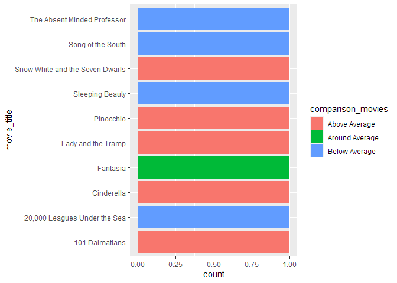

```r
library(ggplot2)
ggplot(data = DisneyMovies4, aes(x = movie_title, fill = comparison_movies)) +
    geom_bar(position = "dodge")+coord_flip()
```

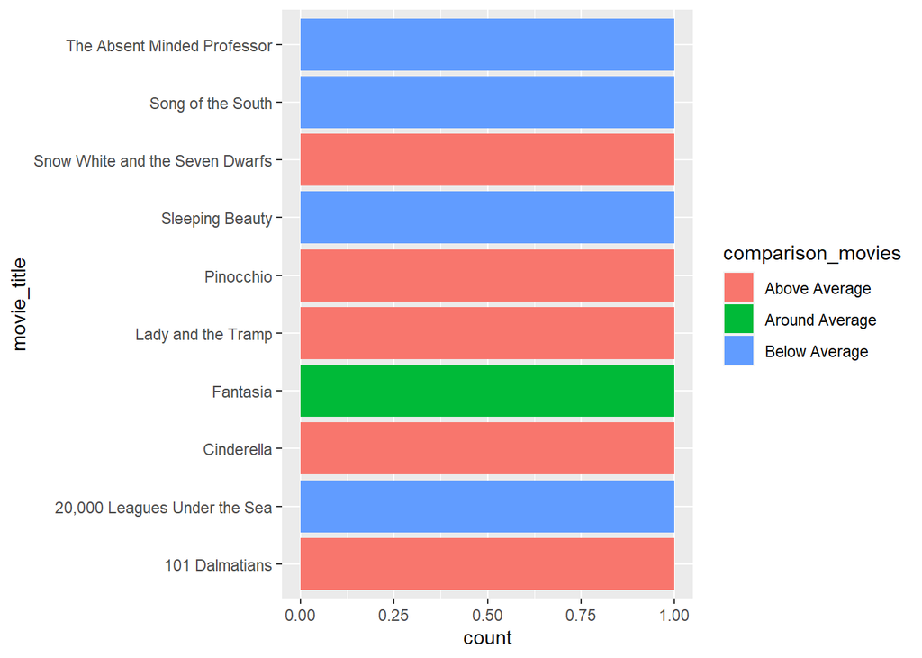

```r
ggplot(data = DisneyMovies4,aes(x = movie_title,fill = comparison_movies))+
  geom_bar(position = "dodge")+
  coord_flip()
```

### Extension of code By Tage N Singh April 24 2021

```r
library(ggplot2)
library(latex2exp)

dis_mov <- as.data.frame(disney_movies_total_gross)

#dis_mov$genre == ""

dis_mov$genre[dis_mov$genre == ""] <- "Unknown" # finxing the genre field for blank values

#dis_mov$genre == ""

dis_genre <- dis_mov %>%
select(genre,total_gross,inflation_adjusted_gross) %>%
group_by(genre) # grouping by genre


dis_genre_tots <- aggregate(cbind(total_gross,inflation_adjusted_gross)~genre,data=dis_genre,FUN=mean)

dis_genre_tots$total_gross <- dis_genre_tots$total_gross/1000000

dis_genre_tots$inflation_adjusted_gross <- dis_genre_tots$inflation_adjusted_gross/1000000

head(dis_genre_tots, 13)
```

```
##                  genre total_gross inflation_adjusted_gross
## 1               Action  104.614082                137.47342
## 2            Adventure  127.047050                190.39741
## 3         Black Comedy   32.514404                 52.24349
## 4               Comedy   44.613295                 84.66773
## 5  Concert/Performance   51.728233                 57.41084
## 6          Documentary   11.292851                 12.71803
## 7                Drama   36.026079                 71.89302
## 8               Horror   14.511479                 23.41385
## 9              Musical   72.330260                603.59786
## 10     Romantic Comedy   50.095950                 77.77708
## 11   Thriller/Suspense   58.616938                 89.65379
## 12             Unknown    6.943942                 21.62373
## 13             Western   51.287351                 73.81571
```

```r
summary(dis_genre_tots)
```

```
##     genre            total_gross      inflation_adjusted_gross
##  Length:13          Min.   :  6.944   Min.   : 12.72
##  Class :character   1st Qu.: 32.514   1st Qu.: 52.24
##  Mode  :character   Median : 50.096   Median : 73.82
##                     Mean   : 50.894   Mean   :115.13
##                     3rd Qu.: 58.617   3rd Qu.: 89.65
##                     Max.   :127.047   Max.   :603.60
```

```r
library(lubridate)
str(disney_movies_total_gross$release_date) # testing the format for date
```

```
##  chr [1:579] "12/21/1937" "2/9/1940" "11/13/1940" "11/12/1946" "2/15/1950" ...
```

```r
disney_movies_total_gross$year <- str_sub(disney_movies_total_gross$release_date, start= -4)

dis_mov2 <- data.frame(disney_movies_total_gross)


dis_year <- dis_mov2 %>%
select(year,total_gross,inflation_adjusted_gross) %>%
group_by(year, ) # grouping by year

dis_year_tots <- aggregate(cbind(total_gross,inflation_adjusted_gross)~year,data=dis_year,FUN=mean)

dis_year_tots$total_gross <- dis_year_tots$total_gross/1000000

dis_year_tots$inflation_adjusted_gross <- dis_year_tots$inflation_adjusted_gross/1000000


dis_year_tots$total_gross <- format(round(dis_year_tots$total_gross, 0), nsmall = 0)

dis_year_tots$inflation_adjusted_gross <- format(round(dis_year_tots$inflation_adjusted_gross, 0), nsmall = 0)

dis_year_tots
```

```
##    year total_gross inflation_adjusted_gross
## 1  1937         185                     5229
## 2  1940          84                     2188
## 3  1946          65                     1079
## 4  1950          85                      921
## 5  1954          28                      528
## 6  1955          94                     1236
## 7  1959           9                       22
## 8  1961          63                      599
## 9  1962           9                      110
## 10 1963          22                      154
## 11 1967         142                      790
## 12 1968          22                      139
## 13 1970          37                      178
## 14 1971          18                       91
```

[output cut: 40 more lines]

```r
str(dis_year_tots)
```

```
## 'data.frame':    54 obs. of  3 variables:
##  $ year                    : chr  "1937" "1940" "1946" "1950" ...
##  $ total_gross             : chr  "185" " 84" " 65" " 85" ...
##  $ inflation_adjusted_gross: chr  "5229" "2188" "1079" " 921" ...
```

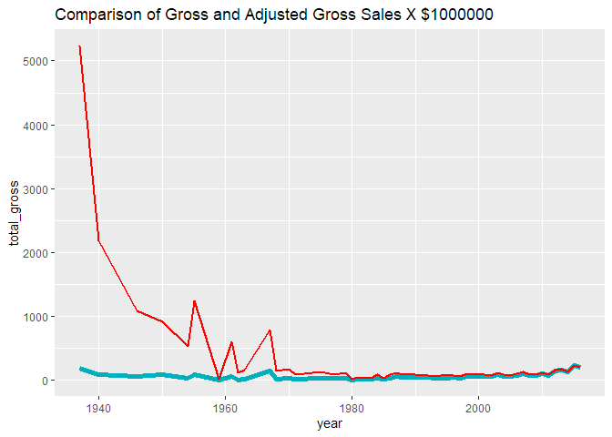

```r
dis_year_tots$year <- as.numeric(as.character(dis_year_tots$year))

dis_year_tots$total_gross <- as.numeric(as.character(dis_year_tots$total_gross))

dis_year_tots$inflation_adjusted_gross <- as.numeric(as.character(dis_year_tots$inflation_adjusted_gross))


#ggplot(data = dis_year_tots, aes(x = year, y = total_gross))+
#  geom_line(color = "#00AFBB", size = 2)



ggplot(dis_year_tots, aes(x=year)) +
  geom_line(aes(y = total_gross), color = "#00AFBB", size=2) +
  geom_line(aes(y = inflation_adjusted_gross), color="red", size = 1) +
  ggtitle("Comparison of Gross and Adjusted Gross Sales X $1000000")
```

## But wait - there’s more we can do with Forcats (Eric Hirsch revision)

In addition to creating categories as shown above, the Forcats package helps us solve many other problems related to the display of categorical variables. For example:

```
 1. How do we display a category by its frequency?
    2. How can we reduce our categories by creating an "other" category
    3. How can we order a category by another variable?
```

Or for even more advanced Forcats functionality:

```
 4. How can we make our catgeories anonymous?
    5. How can we shuffle our categoires in random order?
```

#### 1. Display a category by its count frequency - we use fct_infreq(). We will also use fct_rev() to reverse the default order of fct_infreq - which sorts columns from smallest to largest::

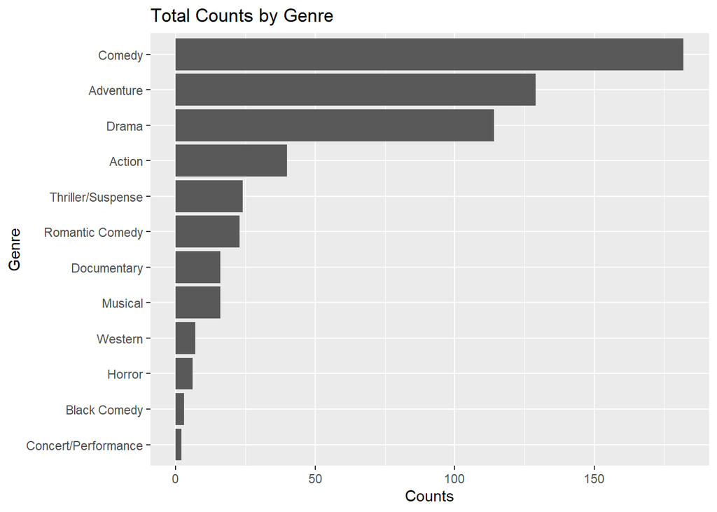

```r
Disney5 <-
  disney_movies_total_gross %>%
    filter(genre!="")

(g1 <-
  ggplot(Disney5, aes(x=fct_rev(fct_infreq(genre)))) +
  geom_bar() +
  coord_flip() +
  ggtitle("Total Counts by Genre") +
  ylab("Counts") +
  xlab("Genre"))
```

#### 2. Create an “other” category to collect together the smaller categories.

Forcats has many ways to do this, with many options for choosing which categories to collect - here we use fct_lump() which combines the categories below a specified n parameter:

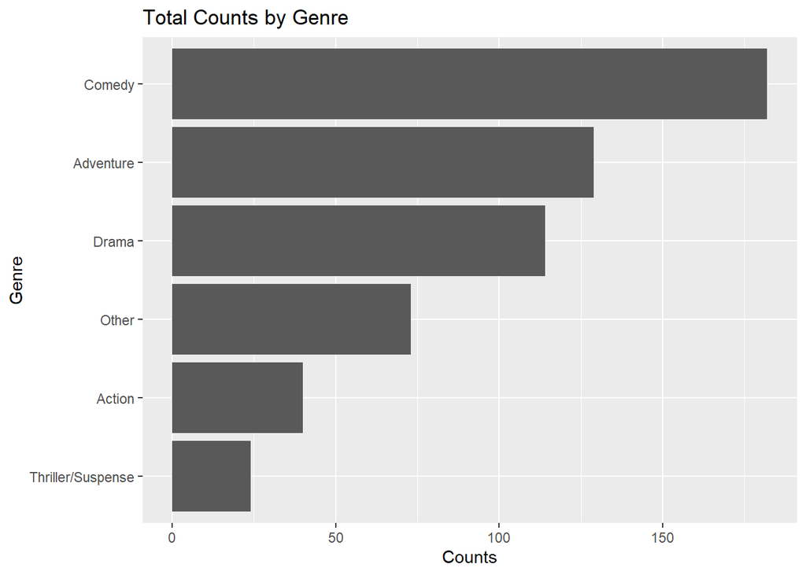

```r
Disney6 <-
  disney_movies_total_gross %>%
    filter(genre!="") %>%
      mutate(genre = fct_lump(genre, n=5))

(g1 <-
  ggplot(Disney6, aes(x=fct_rev(fct_infreq(genre)))) +
  geom_bar() +
  coord_flip() +
  ggtitle("Total Counts by Genre") +
  ylab("Counts") +
  xlab("Genre"))
```

#### 3. Reorder a category based on another category - here we use ftc_reorder to reorder our genre by revenue generated:

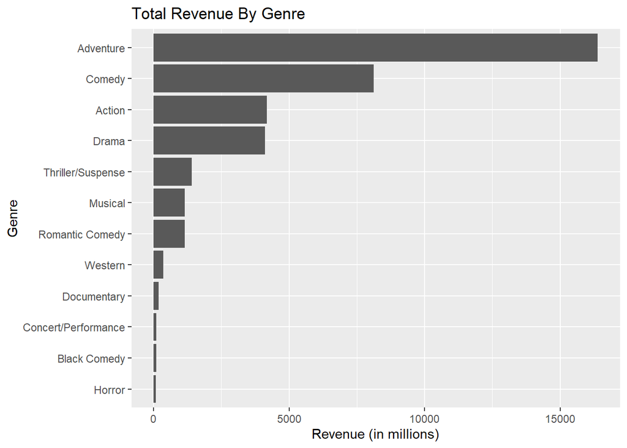

```r
Disney6 <- disney_movies_total_gross %>%
  group_by(genre) %>%
    filter(genre!="") %>%
      summarize(Revenue= sum(round(total_gross/1000000)))


ggplot(Disney6, aes(x=fct_reorder(genre, Revenue),  y=Revenue)) +
  geom_col() +
  coord_flip() +
  ggtitle("Total Revenue By Genre") +
  ylab("Revenue (in millions)") +
  xlab("Genre")
```

#### 4. Make a category anonymous - we use fct_anon():

Imagine every movie has one chief hair stylist who gets rated 1-10 for each movie they work on. Management is interested in analyzing these ratings to look for trends compared to the previous year, and they plan to present the findings at a general staff meeting. However, management is interested in trends - not individual performance- and would like you to hide the individual names from the graph.

First we show the graph as it would appear without anonymizing:

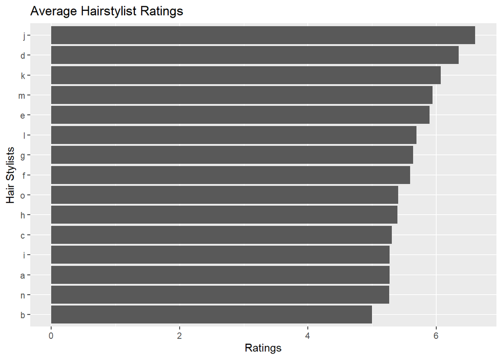

```r
set.seed("12348")
Disney7 <- disney_movies_total_gross %>%
  mutate(hair_stylist = factor(sample(letters[1:15], 579, replace = TRUE))) %>%
  mutate(hair_stylist_rating = sample(10, 579, rep=TRUE)) %>%
  group_by(hair_stylist) %>%
  summarize(AveRating=mean(hair_stylist_rating))

(g1 <-
  ggplot(Disney7, aes(x=fct_reorder(hair_stylist, AveRating),  y=AveRating)) +
  geom_col() +
  coord_flip() +
  ggtitle("Average Hairstylist Ratings") +
  ylab("Ratings") +
  xlab("Hair Stylists"))
```

With fct_anon we can make categories anonymous simply and effectively:

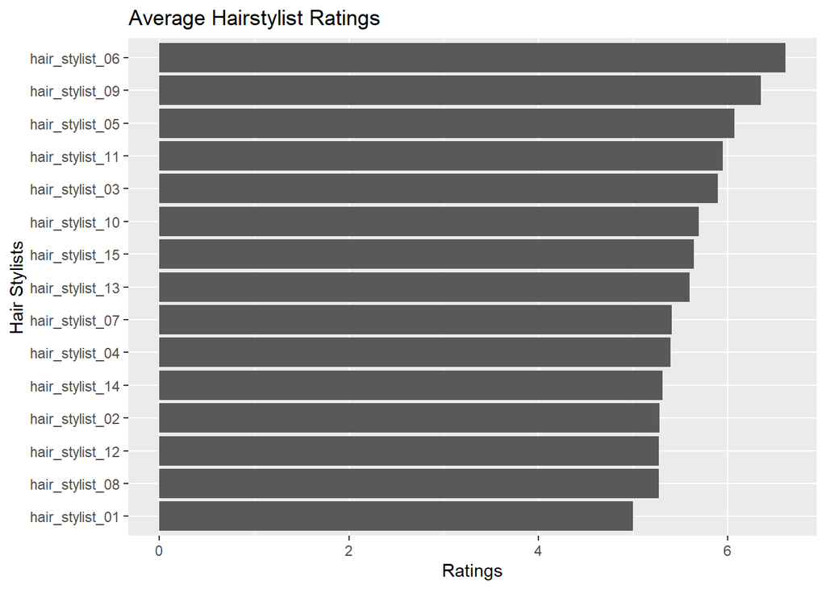

```r
Disney7$hair_stylist2 <-
  fct_anon(Disney7$hair_stylist, "hair_stylist_")

(g1 <-
  ggplot(Disney7, aes(x=fct_reorder(hair_stylist2, AveRating),  y=AveRating)) +
  geom_col() +
  coord_flip() +
  ggtitle("Average Hairstylist Ratings") +
  ylab("Ratings") +
  xlab("Hair Stylists"))
```

#### 5. For our last piece of functionality we will use fct_shuffle() to randomly shuffle our category order.

The Hairstylist Review committee is holding their monthly meeting where hairstylists will present their latest ideas. You always put the presentation list in alphabetical, reverse alphabetical order or rating order - styists ‘e’,‘f’ and ‘g’ are demanding your resignation since they never get to go first. Senior management asks you to randomize the order - you can do it easily with fct_shuffle().

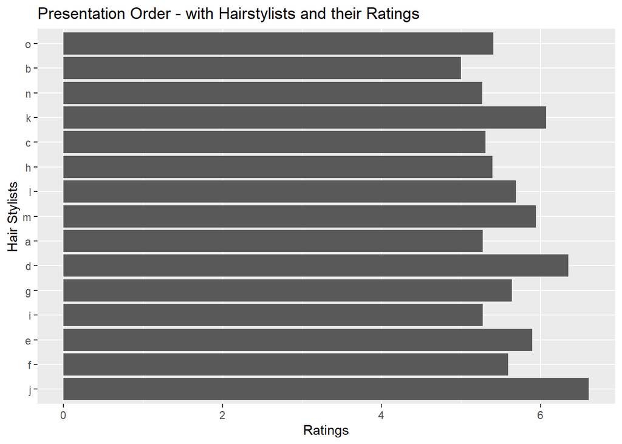

```r
Disney5 <-
  disney_movies_total_gross %>%
  group_by(genre) %>%
  mutate(Revenue= sum(total_gross)) %>%
  filter(genre!="")

ggplot(Disney7, aes(x=fct_shuffle(hair_stylist),  y=AveRating)) +
  geom_col() +
  coord_flip() +
  ggtitle("Presentation Order - with Hairstylists and their Ratings") +
  ylab("Ratings") +
  xlab("Hair Stylists")
```

Alas, “f” is still near the bottom of the list, but random is random.

### Conclusion 2

Factors make categories easy to use in R, and forcats makes it easy to manipulate them.

### Tidyverse Extend

Selecting movies release from 1937 to 1961 can also be done using `filter()` function from the `dplyr` package as shown below. Doing so will select the same rows and columns as specifying `DisneyMovies[1:10,]` and `select(1)`. The select function can also be used to attain the total_gross column AND create `comparison_movies` column, all in this same chunk

**NOTE** The date in format *month/day/year* which it presently is, is most likely of class character. This can be verified with the function `class()` as shown below. In order to use the dates to filter, they can temporarily be modified using `mutate()`

```r
class(disney_movies_total_gross$release_date)
```

```
## [1] "character"
```

```r
(DisneyMovies1_ext<-disney_movies_total_gross%>%
                select(movie_title,release_date,total_gross)%>%
                  filter(
                    as.Date(release_date,format = "%m/%d/%Y") > "1937-1-1" &
                    as.Date(release_date,format = "%m/%d/%Y") < "1961-12-1" )%>%
                        mutate(comparison_movies=case_when(
      total_gross < 81219150 ~ "Below Average",
      total_gross > 81219150  & total_gross <83810000 ~ "Around Average",
      TRUE ~ "Above Average"))%>%
        select(movie_title,release_date, total_gross,comparison_movies)
 )
```

```
##                        movie_title release_date total_gross comparison_movies
## 1  Snow White and the Seven Dwarfs   12/21/1937   184925485     Above Average
## 2                        Pinocchio     2/9/1940    84300000     Above Average
## 3                         Fantasia   11/13/1940    83320000    Around Average
## 4                Song of the South   11/12/1946    65000000     Below Average
## 5                       Cinderella    2/15/1950    85000000     Above Average
## 6     20,000 Leagues Under the Sea   12/23/1954    28200000     Below Average
## 7               Lady and the Tramp    6/22/1955    93600000     Above Average
## 8                  Sleeping Beauty    1/29/1959     9464608     Below Average
## 9                   101 Dalmatians    1/25/1961   153000000     Above Average
## 10     The Absent Minded Professor    3/16/1961    25381407     Below Average
```

The `summary()` function can still be used with this larger data.frame, but the column `total_gross` needs to be subsetted.

```r
summary(DisneyMovies1_ext$total_gross)
```

```
##      Min.   1st Qu.    Median      Mean   3rd Qu.      Max.
##   9464608  37400000  83810000  81219150  91450000 184925485
```

The interesting thing about the options for `ggplot()` is that the `fill` option, essentially works as a factor, *IF* a column name is used over a specific color.

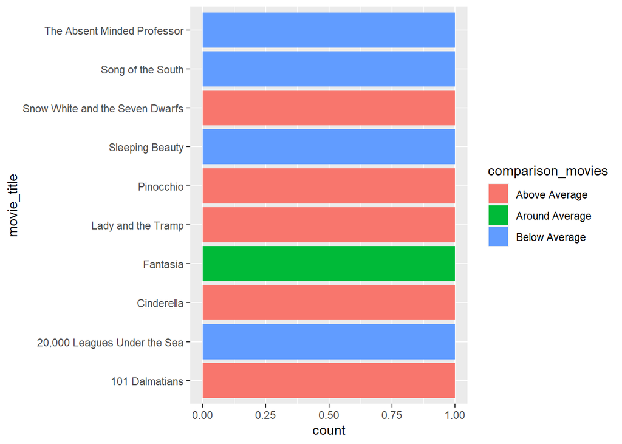

```r
ggplot(data = DisneyMovies1_ext,aes(x = movie_title,fill = comparison_movies))+
  geom_bar(position = "dodge")+
  coord_flip()
```

My favorite feature of the `dplyr` package is the ability to pipe `%>%` within another function. As an example, I piped the data, in the same way it was used to create `Disney5` data.frame, only I did so from within the `ggplot()` function and I factored the columns by genre using `fill`

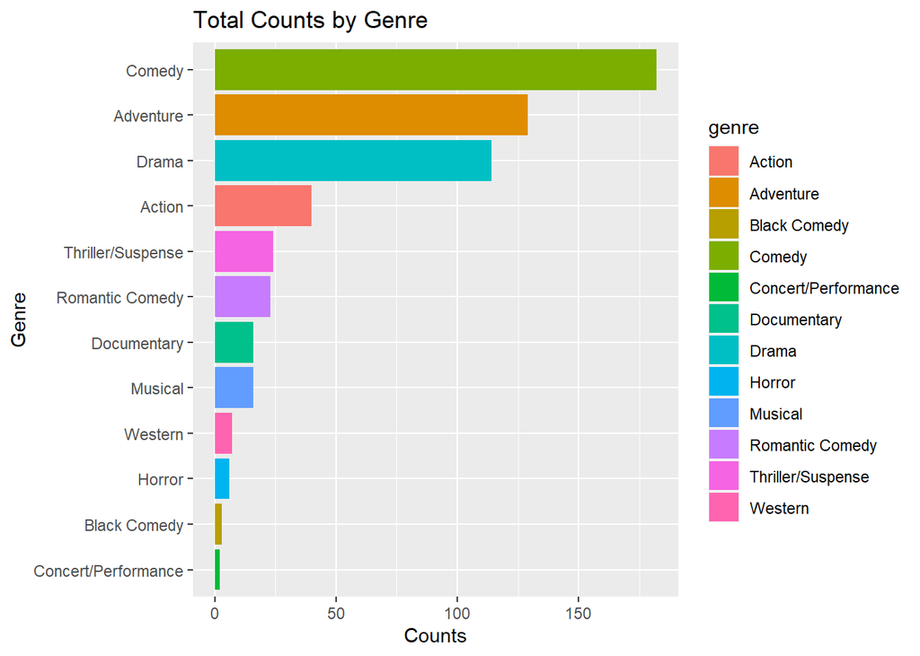

```r
(g1 <-
  ggplot(disney_movies_total_gross %>%
           filter(genre!=""),
         aes(x=fct_rev(fct_infreq(genre)),fill = genre)) +
  geom_bar() +
  coord_flip() +
  ggtitle("Total Counts by Genre") +
  ylab("Counts") +
  xlab("Genre"))
```

Finally, `ggplot()` has various features that can really enhance the visualizations I create. In this very simple example, I add the count to the plot, which originally used `Disney6` data.frame, which depending on the circumstances can add value to the visual representation.

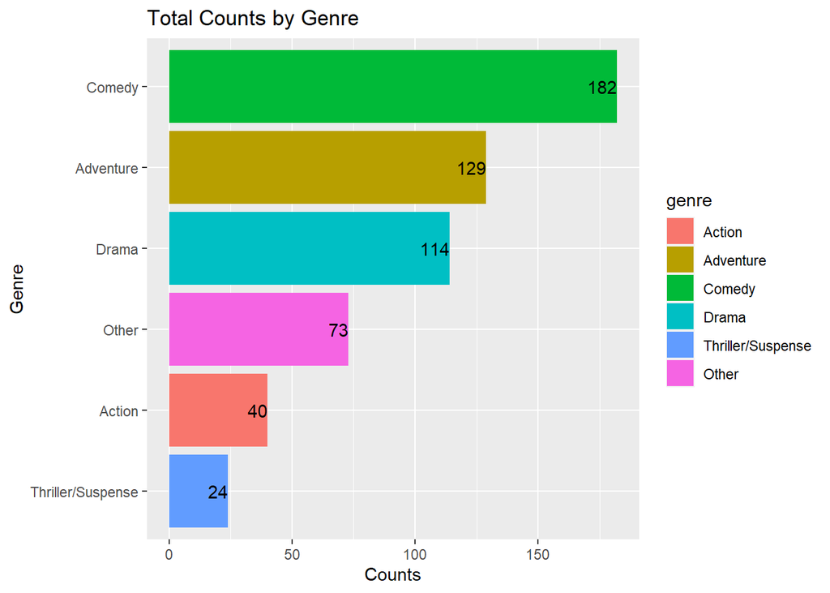

```r
(g1 <-
  ggplot(disney_movies_total_gross %>%
            filter(genre!="") %>%
              mutate(genre = fct_lump(genre, n=5)),
              aes(x=fct_rev(fct_infreq(genre)), fill = genre)) +
  geom_bar() +
  geom_text(stat='count', aes(label=..count..), hjust=1)+
  coord_flip() +
  ggtitle("Total Counts by Genre") +
  ylab("Counts") +
  xlab("Genre"))
```